# HW 9

## Pt C

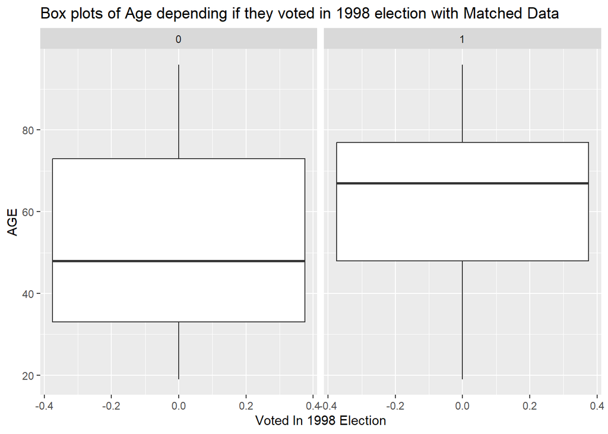

```
## # A tibble: 2 × 6
##   voted1998 Minimum `1st Quartile` Median `3rd Quartile` Maximum
##       <int>   <int>          <dbl>  <int>          <dbl>   <int>
## 1         0      19             33     48             73      96
## 2         1      19             48     67             77      96
```

```
##         voted1998
## MAJORPTY         0         1
##        0 0.2528548 0.1518987
##        1 0.7471452 0.8481013
```

```
##         GOTV_call
## MAJORPTY         0         1
##        0 0.1927126 0.1983806
##        1 0.8072874 0.8016194
```

```
##          voted1998
## voted1996         0         1
##         0 0.5106036 0.1300345
##         1 0.4893964 0.8699655
```

```
##          GOTV_call
## voted1996         0         1
##         0 0.2874494 0.2874494
##         1 0.7125506 0.7125506
```

```
##          GOTV_call
## voted1998         0         1
##         0 0.4259109 0.3522267
##         1 0.5740891 0.6477733
```

```
##
##  2-sample test for equality of proportions with continuity correction
##
## data:  tally(voted1998 ~ GOTV_call)
## X-squared = 4.3089, df = 1, p-value = 0.03791
## alternative hypothesis: two.sided
## 95 percent confidence interval:
##  0.005611728 0.141756693
## sample estimates:
##    prop 1    prop 2
## 0.4259109 0.3522267
```

After matching the data, all of the people came from the same range of years (19-96). Next the proportion of people that were registered with majority party and voted and who didn’t get the call matched to 80% of both subsets. Similarly, the proportion of people who voted in 1996 election & voted and who didn’t get the call matched to 71% of both subsets.

### What do you conclude about the overall effect of the GOTV call on the likelihood of voting in the 1998 election?

After matching the data to GOTV calls, confirming matching of the data, and bootstrapping I can say with 95% confidence (p value < 0.05) that getting a GOTV call increase the chance of someone voting by 0.5%-14.1%.